# Risk Factor Analysis

## Outcome Variable

**Outcome Variable:** whz

## Predictor Variables

**Intervention Variable:** impsan

**Adjustment Set:**

- arm
- sex
- W_mage
- meducyrs
- feducyrs
- hhwealth_quart
- hfoodsec
- W_mhtcm
- W_mwtkg
- W_mbmi
- W_nrooms
- W_nchldlt5
- W_parity
- impfloor
- safeh20
- delta_W_mage
- delta_meducyrs
- delta_feducyrs
- delta_hhwealth_quart
- delta_hfoodsec
- delta_W_mhtcm
- delta_W_mwtkg
- delta_W_mbmi
- delta_W_nrooms
- delta_W_nchldlt5
- delta_W_parity
- delta_impfloor
- delta_safeh20

## Stratifying Variables

The analysis was stratified on these variable(s):

- agecat
- studyid
- country

## Data Summary

| agecat | studyid | country | impsan | n_cell | n |
| --- | --- | --- | --- | --- | --- |
| Birth | ki0047075b-MAL-ED | BANGLADESH | 1 | 168 | 201 |
| Birth | ki0047075b-MAL-ED | BANGLADESH | 0 | 33 | 201 |
| Birth | ki0047075b-MAL-ED | BRAZIL | 1 | 56 | 57 |
| Birth | ki0047075b-MAL-ED | BRAZIL | 0 | 1 | 57 |
| Birth | ki0047075b-MAL-ED | INDIA | 1 | 14 | 39 |
| Birth | ki0047075b-MAL-ED | INDIA | 0 | 25 | 39 |
| Birth | ki0047075b-MAL-ED | NEPAL | 1 | 24 | 25 |
| Birth | ki0047075b-MAL-ED | NEPAL | 0 | 1 | 25 |
| Birth | ki0047075b-MAL-ED | PERU | 1 | 50 | 203 |
| Birth | ki0047075b-MAL-ED | PERU | 0 | 153 | 203 |
| Birth | ki0047075b-MAL-ED | SOUTH AFRICA | 1 | 0 | 94 |
| Birth | ki0047075b-MAL-ED | SOUTH AFRICA | 0 | 94 | 94 |
| Birth | ki0047075b-MAL-ED | TANZANIA, UNITED REPUBLIC OF | 1 | 0 | 110 |
| Birth | ki0047075b-MAL-ED | TANZANIA, UNITED REPUBLIC OF | 0 | 110 | 110 |
| Birth | ki1017093-NIH-Birth | BANGLADESH | 1 | 222 | 575 |
| Birth | ki1017093-NIH-Birth | BANGLADESH | 0 | 353 | 575 |
| Birth | ki1017093b-PROVIDE | BANGLADESH | 1 | 43 | 45 |
| Birth | ki1017093b-PROVIDE | BANGLADESH | 0 | 2 | 45 |
| Birth | ki1017093c-NIH-Crypto | BANGLADESH | 1 | 610 | 696 |
| Birth | ki1017093c-NIH-Crypto | BANGLADESH | 0 | 86 | 696 |
| Birth | ki1114097-CONTENT | PERU | 1 | 1 | 2 |
| Birth | ki1114097-CONTENT | PERU | 0 | 1 | 2 |
| Birth | ki1135781-COHORTS | GUATEMALA | 1 | 43 | 449 |
| Birth | ki1135781-COHORTS | GUATEMALA | 0 | 406 | 449 |
| Birth | ki1135781-COHORTS | INDIA | 1 | 1685 | 4461 |
| Birth | ki1135781-COHORTS | INDIA | 0 | 2776 | 4461 |
| Birth | ki1135781-COHORTS | PHILIPPINES | 1 | 177 | 1126 |
| Birth | ki1135781-COHORTS | PHILIPPINES | 0 | 949 | 1126 |
| Birth | kiGH5241-JiVitA-3 | BANGLADESH | 1 | 15611 | 22057 |
| Birth | kiGH5241-JiVitA-3 | BANGLADESH | 0 | 6446 | 22057 |

[output cut: 70 more lines]

The following strata were considered:

- agecat: 24 months, studyid: ki0047075b-MAL-ED, country: BANGLADESH
- agecat: 24 months, studyid: ki0047075b-MAL-ED, country: BRAZIL
- agecat: 24 months, studyid: ki0047075b-MAL-ED, country: INDIA
- agecat: 24 months, studyid: ki0047075b-MAL-ED, country: NEPAL
- agecat: 24 months, studyid: ki0047075b-MAL-ED, country: PERU
- agecat: 24 months, studyid: ki0047075b-MAL-ED, country: SOUTH AFRICA
- agecat: 24 months, studyid: ki0047075b-MAL-ED, country: TANZANIA, UNITED REPUBLIC OF
- agecat: 24 months, studyid: ki1017093-NIH-Birth, country: BANGLADESH
- agecat: 24 months, studyid: ki1017093b-PROVIDE, country: BANGLADESH
- agecat: 24 months, studyid: ki1017093c-NIH-Crypto, country: BANGLADESH
- agecat: 24 months, studyid: ki1114097-CONTENT, country: PERU
- agecat: 24 months, studyid: ki1135781-COHORTS, country: GUATEMALA
- agecat: 24 months, studyid: ki1135781-COHORTS, country: INDIA
- agecat: 24 months, studyid: ki1135781-COHORTS, country: PHILIPPINES
- agecat: 24 months, studyid: ki1148112-LCNI-5, country: MALAWI
- agecat: 24 months, studyid: kiGH5241-JiVitA-3, country: BANGLADESH
- agecat: 24 months, studyid: kiGH5241-JiVitA-4, country: BANGLADESH
- agecat: 6 months, studyid: ki0047075b-MAL-ED, country: BANGLADESH
- agecat: 6 months, studyid: ki0047075b-MAL-ED, country: BRAZIL
- agecat: 6 months, studyid: ki0047075b-MAL-ED, country: INDIA
- agecat: 6 months, studyid: ki0047075b-MAL-ED, country: NEPAL
- agecat: 6 months, studyid: ki0047075b-MAL-ED, country: PERU
- agecat: 6 months, studyid: ki0047075b-MAL-ED, country: SOUTH AFRICA
- agecat: 6 months, studyid: ki0047075b-MAL-ED, country: TANZANIA, UNITED REPUBLIC OF
- agecat: 6 months, studyid: ki1017093-NIH-Birth, country: BANGLADESH
- agecat: 6 months, studyid: ki1017093b-PROVIDE, country: BANGLADESH
- agecat: 6 months, studyid: ki1017093c-NIH-Crypto, country: BANGLADESH
- agecat: 6 months, studyid: ki1114097-CONTENT, country: PERU
- agecat: 6 months, studyid: ki1135781-COHORTS, country: GUATEMALA
- agecat: 6 months, studyid: ki1135781-COHORTS, country: INDIA
- agecat: 6 months, studyid: ki1135781-COHORTS, country: PHILIPPINES
- agecat: 6 months, studyid: ki1148112-LCNI-5, country: MALAWI
- agecat: 6 months, studyid: kiGH5241-JiVitA-3, country: BANGLADESH
- agecat: 6 months, studyid: kiGH5241-JiVitA-4, country: BANGLADESH
- agecat: Birth, studyid: ki0047075b-MAL-ED, country: BANGLADESH
- agecat: Birth, studyid: ki0047075b-MAL-ED, country: BRAZIL
- agecat: Birth, studyid: ki0047075b-MAL-ED, country: INDIA
- agecat: Birth, studyid: ki0047075b-MAL-ED, country: NEPAL
- agecat: Birth, studyid: ki0047075b-MAL-ED, country: PERU
- agecat: Birth, studyid: ki0047075b-MAL-ED, country: SOUTH AFRICA
- agecat: Birth, studyid: ki0047075b-MAL-ED, country: TANZANIA, UNITED REPUBLIC OF
- agecat: Birth, studyid: ki1017093-NIH-Birth, country: BANGLADESH
- agecat: Birth, studyid: ki1017093b-PROVIDE, country: BANGLADESH
- agecat: Birth, studyid: ki1017093c-NIH-Crypto, country: BANGLADESH
- agecat: Birth, studyid: ki1114097-CONTENT, country: PERU
- agecat: Birth, studyid: ki1135781-COHORTS, country: GUATEMALA
- agecat: Birth, studyid: ki1135781-COHORTS, country: INDIA
- agecat: Birth, studyid: ki1135781-COHORTS, country: PHILIPPINES
- agecat: Birth, studyid: kiGH5241-JiVitA-3, country: BANGLADESH
- agecat: Birth, studyid: kiGH5241-JiVitA-4, country: BANGLADESH

### Dropped Strata

Some strata were dropped due to rare outcomes:

- agecat: Birth, studyid: ki0047075b-MAL-ED, country: BRAZIL
- agecat: Birth, studyid: ki0047075b-MAL-ED, country: NEPAL
- agecat: Birth, studyid: ki0047075b-MAL-ED, country: SOUTH AFRICA
- agecat: Birth, studyid: ki0047075b-MAL-ED, country: TANZANIA, UNITED REPUBLIC OF
- agecat: Birth, studyid: ki1017093b-PROVIDE, country: BANGLADESH
- agecat: Birth, studyid: ki1114097-CONTENT, country: PERU
- agecat: 6 months, studyid: ki0047075b-MAL-ED, country: BRAZIL
- agecat: 6 months, studyid: ki0047075b-MAL-ED, country: NEPAL
- agecat: 6 months, studyid: ki0047075b-MAL-ED, country: SOUTH AFRICA
- agecat: 6 months, studyid: ki0047075b-MAL-ED, country: TANZANIA, UNITED REPUBLIC OF
- agecat: 6 months, studyid: ki1017093b-PROVIDE, country: BANGLADESH
- agecat: 6 months, studyid: ki1148112-LCNI-5, country: MALAWI
- agecat: 24 months, studyid: ki0047075b-MAL-ED, country: BRAZIL
- agecat: 24 months, studyid: ki0047075b-MAL-ED, country: NEPAL
- agecat: 24 months, studyid: ki0047075b-MAL-ED, country: SOUTH AFRICA
- agecat: 24 months, studyid: ki0047075b-MAL-ED, country: TANZANIA, UNITED REPUBLIC OF
- agecat: 24 months, studyid: ki1017093b-PROVIDE, country: BANGLADESH
- agecat: 24 months, studyid: ki1148112-LCNI-5, country: MALAWI

## Methods Detail

We’re interested in the causal parameters $E[Y_a]$ for all values of $a \in \mathcal{A}$. These parameters represent the mean outcome if, possibly contrary to fact, we intervened to set all units to have $A=a$. Under the randomization and positivity assumptions, these are identified by the statistical parameters $\psi_a=E_W[E_{Y|A,W}(Y|A=a,W)]$. In addition, we’re interested in the mean of $Y$, $E[Y]$ under no intervention (the observed mean). We will estimate these parameters by using SuperLearner to fit the relevant likelihood factors – $E_{Y|A,W}(Y|A=a,W)$ and $p(A=a|W)$, and then updating our likelihood fit using a joint TMLE.

For unadjusted analyses ($W=\{\}$), initial likelihoods were estimated using Lrnr_glm to estimate the simple $E(Y|A)$ and Lrnr_mean to estimate $p(A)$. For adjusted analyses, a small library containing Lrnr_glmnet, Lrnr_xgboost, and Lrnr_mean was used.

Having estimated these parameters, we will then use the delta method to estimate relative risks and attributable risks relative to a prespecified baseline level of $A$.

# Results Detail

## Results Plots

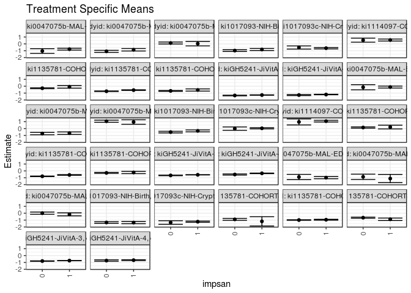

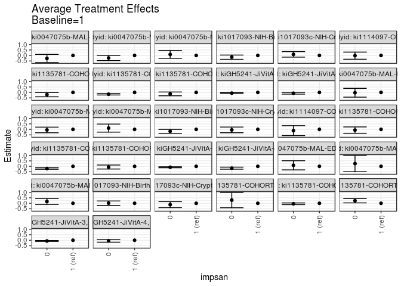

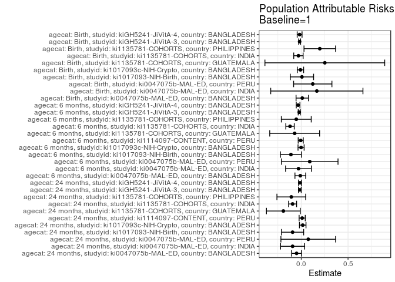

## Results Table

### Parameter: TSM

| agecat | studyid | country | intervention_level | baseline_level | estimate | ci_lower | ci_upper |
| --- | --- | --- | --- | --- | --- | --- | --- |
| Birth | ki0047075b-MAL-ED | BANGLADESH | 1 | NA | -0.9827261 | -1.1442502 | -0.8212020 |
| Birth | ki0047075b-MAL-ED | BANGLADESH | 0 | NA | -0.8881218 | -1.2714468 | -0.5047968 |
| Birth | ki0047075b-MAL-ED | INDIA | 1 | NA | -1.1104949 | -1.7077723 | -0.5132175 |
| Birth | ki0047075b-MAL-ED | INDIA | 0 | NA | -0.8611645 | -1.2483115 | -0.4740174 |
| Birth | ki0047075b-MAL-ED | PERU | 1 | NA | -0.1610340 | -0.3804517 | 0.0583836 |
| Birth | ki0047075b-MAL-ED | PERU | 0 | NA | 0.0057797 | -0.1576399 | 0.1691994 |
| Birth | ki1017093-NIH-Birth | BANGLADESH | 1 | NA | -1.3569542 | -1.5225546 | -1.1913538 |
| Birth | ki1017093-NIH-Birth | BANGLADESH | 0 | NA | -1.3468438 | -1.4624406 | -1.2312469 |
| Birth | ki1017093c-NIH-Crypto | BANGLADESH | 1 | NA | -1.2313026 | -1.3208133 | -1.1417919 |
| Birth | ki1017093c-NIH-Crypto | BANGLADESH | 0 | NA | -1.3519004 | -1.6112895 | -1.0925114 |
| Birth | ki1135781-COHORTS | GUATEMALA | 1 | NA | -1.1812675 | -1.8601666 | -0.5023685 |
| Birth | ki1135781-COHORTS | GUATEMALA | 0 | NA | -0.8926582 | -1.0357925 | -0.7495240 |
| Birth | ki1135781-COHORTS | INDIA | 1 | NA | -0.9467641 | -1.0091281 | -0.8844000 |
| Birth | ki1135781-COHORTS | INDIA | 0 | NA | -0.9912286 | -1.0358006 | -0.9466567 |
| Birth | ki1135781-COHORTS | PHILIPPINES | 1 | NA | -0.8820889 | -1.0625061 | -0.7016717 |
| Birth | ki1135781-COHORTS | PHILIPPINES | 0 | NA | -0.6473423 | -0.7282751 | -0.5664096 |
| Birth | kiGH5241-JiVitA-3 | BANGLADESH | 1 | NA | -0.7323885 | -0.7533935 | -0.7113834 |
| Birth | kiGH5241-JiVitA-3 | BANGLADESH | 0 | NA | -0.7988347 | -0.8331589 | -0.7645105 |
| Birth | kiGH5241-JiVitA-4 | BANGLADESH | 1 | NA | -0.6706059 | -0.7300674 | -0.6111445 |
| Birth | kiGH5241-JiVitA-4 | BANGLADESH | 0 | NA | -0.7274369 | -0.8306649 | -0.6242088 |
| 6 months | ki0047075b-MAL-ED | BANGLADESH | 1 | NA | -0.1238590 | -0.2651913 | 0.0174734 |
| 6 months | ki0047075b-MAL-ED | BANGLADESH | 0 | NA | -0.1533259 | -0.5282116 | 0.2215597 |
| 6 months | ki0047075b-MAL-ED | INDIA | 1 | NA | -0.6723705 | -0.8556654 | -0.4890755 |
| 6 months | ki0047075b-MAL-ED | INDIA | 0 | NA | -0.7236850 | -0.9023338 | -0.5450362 |
| 6 months | ki0047075b-MAL-ED | PERU | 1 | NA | 0.9497151 | 0.6250792 | 1.2743510 |
| 6 months | ki0047075b-MAL-ED | PERU | 0 | NA | 1.0659168 | 0.9078183 | 1.2240153 |
| 6 months | ki1017093-NIH-Birth | BANGLADESH | 1 | NA | -0.3368261 | -0.4763911 | -0.1972612 |
| 6 months | ki1017093-NIH-Birth | BANGLADESH | 0 | NA | -0.5153468 | -0.6324937 | -0.3981999 |
| 6 months | ki1017093c-NIH-Crypto | BANGLADESH | 1 | NA | 0.0358593 | -0.0479105 | 0.1196290 |
| 6 months | ki1017093c-NIH-Crypto | BANGLADESH | 0 | NA | -0.0112840 | -0.2578535 | 0.2352854 |
| 6 months | ki1114097-CONTENT | PERU | 1 | NA | 1.0741927 | 0.9521015 | 1.1962840 |
| 6 months | ki1114097-CONTENT | PERU | 0 | NA | 0.9620246 | 0.5268172 | 1.3972320 |
| 6 months | ki1135781-COHORTS | GUATEMALA | 1 | NA | 0.2164660 | -0.0576226 | 0.4905545 |
| 6 months | ki1135781-COHORTS | GUATEMALA | 0 | NA | 0.1506978 | 0.0582849 | 0.2431107 |
| 6 months | ki1135781-COHORTS | INDIA | 1 | NA | -0.5903087 | -0.6447884 | -0.5358290 |
| 6 months | ki1135781-COHORTS | INDIA | 0 | NA | -0.7873670 | -0.8296847 | -0.7450494 |
| 6 months | ki1135781-COHORTS | PHILIPPINES | 1 | NA | -0.2295957 | -0.3960533 | -0.0631382 |
| 6 months | ki1135781-COHORTS | PHILIPPINES | 0 | NA | -0.2925924 | -0.3628555 | -0.2223293 |
| 6 months | kiGH5241-JiVitA-3 | BANGLADESH | 1 | NA | -0.5710412 | -0.5940457 | -0.5480367 |
| 6 months | kiGH5241-JiVitA-3 | BANGLADESH | 0 | NA | -0.6553462 | -0.6954483 | -0.6152441 |
| 6 months | kiGH5241-JiVitA-4 | BANGLADESH | 1 | NA | -0.3561478 | -0.3978859 | -0.3144097 |
| 6 months | kiGH5241-JiVitA-4 | BANGLADESH | 0 | NA | -0.5243698 | -0.6090606 | -0.4396790 |
| 24 months | ki0047075b-MAL-ED | BANGLADESH | 1 | NA | -0.7698951 | -0.9007427 | -0.6390476 |
| 24 months | ki0047075b-MAL-ED | BANGLADESH | 0 | NA | -1.0397530 | -1.3821793 | -0.6973266 |
| 24 months | ki0047075b-MAL-ED | INDIA | 1 | NA | -0.8568596 | -1.0364911 | -0.6772281 |
| 24 months | ki0047075b-MAL-ED | INDIA | 0 | NA | -1.0851482 | -1.2335912 | -0.9367053 |
| 24 months | ki0047075b-MAL-ED | PERU | 1 | NA | 0.0322333 | -0.2911823 | 0.3556489 |
| 24 months | ki0047075b-MAL-ED | PERU | 0 | NA | 0.1248959 | -0.0177185 | 0.2675103 |
| 24 months | ki1017093-NIH-Birth | BANGLADESH | 1 | NA | -0.8186283 | -0.9650821 | -0.6721745 |
| 24 months | ki1017093-NIH-Birth | BANGLADESH | 0 | NA | -0.9750538 | -1.1056415 | -0.8444660 |
| 24 months | ki1017093c-NIH-Crypto | BANGLADESH | 1 | NA | -0.6271701 | -0.7323398 | -0.5220004 |
| 24 months | ki1017093c-NIH-Crypto | BANGLADESH | 0 | NA | -0.5269229 | -0.7566089 | -0.2972369 |
| 24 months | ki1114097-CONTENT | PERU | 1 | NA | 0.5571377 | 0.4106832 | 0.7035921 |
| 24 months | ki1114097-CONTENT | PERU | 0 | NA | 0.5381226 | 0.2457930 | 0.8304522 |
| 24 months | ki1135781-COHORTS | GUATEMALA | 1 | NA | -0.0947363 | -0.2807513 | 0.0912787 |
| 24 months | ki1135781-COHORTS | GUATEMALA | 0 | NA | -0.2941739 | -0.3572318 | -0.2311160 |
| 24 months | ki1135781-COHORTS | INDIA | 1 | NA | -0.5678196 | -0.6216876 | -0.5139515 |
| 24 months | ki1135781-COHORTS | INDIA | 0 | NA | -0.7327098 | -0.7756206 | -0.6897991 |
| 24 months | ki1135781-COHORTS | PHILIPPINES | 1 | NA | -0.5499145 | -0.7111151 | -0.3887139 |
| 24 months | ki1135781-COHORTS | PHILIPPINES | 0 | NA | -0.6822669 | -0.7450038 | -0.6195300 |
| 24 months | kiGH5241-JiVitA-3 | BANGLADESH | 1 | NA | -1.2832928 | -1.3117165 | -1.2548692 |
| 24 months | kiGH5241-JiVitA-3 | BANGLADESH | 0 | NA | -1.3473263 | -1.3928553 | -1.3017973 |
| 24 months | kiGH5241-JiVitA-4 | BANGLADESH | 1 | NA | -1.2097367 | -1.2446741 | -1.1747993 |
| 24 months | kiGH5241-JiVitA-4 | BANGLADESH | 0 | NA | -1.2833544 | -1.3573314 | -1.2093774 |

### Parameter: E(Y)

| agecat | studyid | country | intervention_level | baseline_level | estimate | ci_lower | ci_upper |
| --- | --- | --- | --- | --- | --- | --- | --- |
| Birth | ki0047075b-MAL-ED | BANGLADESH | NA | NA | -0.9721393 | -1.1211171 | -0.8231615 |
| Birth | ki0047075b-MAL-ED | INDIA | NA | NA | -0.9441026 | -1.2397919 | -0.6484132 |
| Birth | ki0047075b-MAL-ED | PERU | NA | NA | -0.0381281 | -0.1669868 | 0.0907307 |
| Birth | ki1017093-NIH-Birth | BANGLADESH | NA | NA | -1.3499217 | -1.4444634 | -1.2553801 |
| Birth | ki1017093c-NIH-Crypto | BANGLADESH | NA | NA | -1.2402802 | -1.3249395 | -1.1556208 |
| Birth | ki1135781-COHORTS | GUATEMALA | NA | NA | -0.9294432 | -1.0701697 | -0.7887168 |
| Birth | ki1135781-COHORTS | INDIA | NA | NA | -0.9771733 | -1.0119896 | -0.9423570 |
| Birth | ki1135781-COHORTS | PHILIPPINES | NA | NA | -0.6841030 | -0.7582767 | -0.6099293 |
| Birth | kiGH5241-JiVitA-3 | BANGLADESH | NA | NA | -0.7501016 | -0.7679528 | -0.7322503 |
| Birth | kiGH5241-JiVitA-4 | BANGLADESH | NA | NA | -0.6882498 | -0.7406539 | -0.6358456 |
| 6 months | ki0047075b-MAL-ED | BANGLADESH | NA | NA | -0.1340556 | -0.2631866 | -0.0049245 |
| 6 months | ki0047075b-MAL-ED | INDIA | NA | NA | -0.7020815 | -0.8292964 | -0.5748666 |
| 6 months | ki0047075b-MAL-ED | PERU | NA | NA | 1.0402218 | 0.9168903 | 1.1635533 |
| 6 months | ki1017093-NIH-Birth | BANGLADESH | NA | NA | -0.4474038 | -0.5378167 | -0.3569909 |
| 6 months | ki1017093c-NIH-Crypto | BANGLADESH | NA | NA | 0.0336790 | -0.0458848 | 0.1132428 |
| 6 months | ki1114097-CONTENT | PERU | NA | NA | 1.0684318 | 0.9515274 | 1.1853362 |
| 6 months | ki1135781-COHORTS | GUATEMALA | NA | NA | 0.1458511 | 0.0589571 | 0.2327450 |
| 6 months | ki1135781-COHORTS | INDIA | NA | NA | -0.7104855 | -0.7428053 | -0.6781657 |
| 6 months | ki1135781-COHORTS | PHILIPPINES | NA | NA | -0.2830286 | -0.3471028 | -0.2189545 |
| 6 months | kiGH5241-JiVitA-3 | BANGLADESH | NA | NA | -0.5926506 | -0.6122450 | -0.5730562 |
| 6 months | kiGH5241-JiVitA-4 | BANGLADESH | NA | NA | -0.3901595 | -0.4274150 | -0.3529041 |
| 24 months | ki0047075b-MAL-ED | BANGLADESH | NA | NA | -0.8201887 | -0.9423967 | -0.6979806 |
| 24 months | ki0047075b-MAL-ED | INDIA | NA | NA | -0.9496667 | -1.0657716 | -0.8335618 |
| 24 months | ki0047075b-MAL-ED | PERU | NA | NA | 0.1069898 | -0.0141601 | 0.2281397 |
| 24 months | ki1017093-NIH-Birth | BANGLADESH | NA | NA | -0.9115790 | -1.0095022 | -0.8136559 |
| 24 months | ki1017093c-NIH-Crypto | BANGLADESH | NA | NA | -0.6115706 | -0.7075788 | -0.5155624 |
| 24 months | ki1114097-CONTENT | PERU | NA | NA | 0.5668293 | 0.4302437 | 0.7034148 |
| 24 months | ki1135781-COHORTS | GUATEMALA | NA | NA | -0.2861905 | -0.3461594 | -0.2262216 |
| 24 months | ki1135781-COHORTS | INDIA | NA | NA | -0.6606874 | -0.6938402 | -0.6275347 |
| 24 months | ki1135781-COHORTS | PHILIPPINES | NA | NA | -0.6564149 | -0.7144543 | -0.5983756 |
| 24 months | kiGH5241-JiVitA-3 | BANGLADESH | NA | NA | -1.2986562 | -1.3220237 | -1.2752887 |
| 24 months | kiGH5241-JiVitA-4 | BANGLADESH | NA | NA | -1.2231776 | -1.2550332 | -1.1913220 |

### Parameter: ATE

| agecat | studyid | country | intervention_level | baseline_level | estimate | ci_lower | ci_upper |
| --- | --- | --- | --- | --- | --- | --- | --- |
| Birth | ki0047075b-MAL-ED | BANGLADESH | 1 | 1 | 0.0000000 | 0.0000000 | 0.0000000 |
| Birth | ki0047075b-MAL-ED | BANGLADESH | 0 | 1 | 0.0946043 | -0.3212107 | 0.5104192 |
| Birth | ki0047075b-MAL-ED | INDIA | 1 | 1 | 0.0000000 | 0.0000000 | 0.0000000 |
| Birth | ki0047075b-MAL-ED | INDIA | 0 | 1 | 0.2493305 | -0.4928524 | 0.9915133 |
| Birth | ki0047075b-MAL-ED | PERU | 1 | 1 | 0.0000000 | 0.0000000 | 0.0000000 |
| Birth | ki0047075b-MAL-ED | PERU | 0 | 1 | 0.1668138 | -0.1073244 | 0.4409520 |
| Birth | ki1017093-NIH-Birth | BANGLADESH | 1 | 1 | 0.0000000 | 0.0000000 | 0.0000000 |
| Birth | ki1017093-NIH-Birth | BANGLADESH | 0 | 1 | 0.0101104 | -0.1914955 | 0.2117163 |
| Birth | ki1017093c-NIH-Crypto | BANGLADESH | 1 | 1 | 0.0000000 | 0.0000000 | 0.0000000 |
| Birth | ki1017093c-NIH-Crypto | BANGLADESH | 0 | 1 | -0.1205978 | -0.3951045 | 0.1539089 |
| Birth | ki1135781-COHORTS | GUATEMALA | 1 | 1 | 0.0000000 | 0.0000000 | 0.0000000 |
| Birth | ki1135781-COHORTS | GUATEMALA | 0 | 1 | 0.2886093 | -0.4056031 | 0.9828218 |
| Birth | ki1135781-COHORTS | INDIA | 1 | 1 | 0.0000000 | 0.0000000 | 0.0000000 |
| Birth | ki1135781-COHORTS | INDIA | 0 | 1 | -0.0444646 | -0.1211041 | 0.0321750 |
| Birth | ki1135781-COHORTS | PHILIPPINES | 1 | 1 | 0.0000000 | 0.0000000 | 0.0000000 |
| Birth | ki1135781-COHORTS | PHILIPPINES | 0 | 1 | 0.2347466 | 0.0374710 | 0.4320222 |
| Birth | kiGH5241-JiVitA-3 | BANGLADESH | 1 | 1 | 0.0000000 | 0.0000000 | 0.0000000 |
| Birth | kiGH5241-JiVitA-3 | BANGLADESH | 0 | 1 | -0.0664462 | -0.1041240 | -0.0287684 |
| Birth | kiGH5241-JiVitA-4 | BANGLADESH | 1 | 1 | 0.0000000 | 0.0000000 | 0.0000000 |
| Birth | kiGH5241-JiVitA-4 | BANGLADESH | 0 | 1 | -0.0568309 | -0.1741519 | 0.0604901 |
| 6 months | ki0047075b-MAL-ED | BANGLADESH | 1 | 1 | 0.0000000 | 0.0000000 | 0.0000000 |
| 6 months | ki0047075b-MAL-ED | BANGLADESH | 0 | 1 | -0.0294669 | -0.4306456 | 0.3717117 |
| 6 months | ki0047075b-MAL-ED | INDIA | 1 | 1 | 0.0000000 | 0.0000000 | 0.0000000 |
| 6 months | ki0047075b-MAL-ED | INDIA | 0 | 1 | -0.0513145 | -0.3080763 | 0.2054473 |
| 6 months | ki0047075b-MAL-ED | PERU | 1 | 1 | 0.0000000 | 0.0000000 | 0.0000000 |
| 6 months | ki0047075b-MAL-ED | PERU | 0 | 1 | 0.1162017 | -0.2497841 | 0.4821876 |
| 6 months | ki1017093-NIH-Birth | BANGLADESH | 1 | 1 | 0.0000000 | 0.0000000 | 0.0000000 |
| 6 months | ki1017093-NIH-Birth | BANGLADESH | 0 | 1 | -0.1785207 | -0.3601055 | 0.0030642 |
| 6 months | ki1017093c-NIH-Crypto | BANGLADESH | 1 | 1 | 0.0000000 | 0.0000000 | 0.0000000 |
| 6 months | ki1017093c-NIH-Crypto | BANGLADESH | 0 | 1 | -0.0471433 | -0.3072844 | 0.2129978 |
| 6 months | ki1114097-CONTENT | PERU | 1 | 1 | 0.0000000 | 0.0000000 | 0.0000000 |
| 6 months | ki1114097-CONTENT | PERU | 0 | 1 | -0.1121681 | -0.5648848 | 0.3405486 |
| 6 months | ki1135781-COHORTS | GUATEMALA | 1 | 1 | 0.0000000 | 0.0000000 | 0.0000000 |
| 6 months | ki1135781-COHORTS | GUATEMALA | 0 | 1 | -0.0657681 | -0.3547486 | 0.2232123 |
| 6 months | ki1135781-COHORTS | INDIA | 1 | 1 | 0.0000000 | 0.0000000 | 0.0000000 |
| 6 months | ki1135781-COHORTS | INDIA | 0 | 1 | -0.1970584 | -0.2659500 | -0.1281668 |
| 6 months | ki1135781-COHORTS | PHILIPPINES | 1 | 1 | 0.0000000 | 0.0000000 | 0.0000000 |
| 6 months | ki1135781-COHORTS | PHILIPPINES | 0 | 1 | -0.0629966 | -0.2441637 | 0.1181704 |
| 6 months | kiGH5241-JiVitA-3 | BANGLADESH | 1 | 1 | 0.0000000 | 0.0000000 | 0.0000000 |
| 6 months | kiGH5241-JiVitA-3 | BANGLADESH | 0 | 1 | -0.0843050 | -0.1289061 | -0.0397039 |
| 6 months | kiGH5241-JiVitA-4 | BANGLADESH | 1 | 1 | 0.0000000 | 0.0000000 | 0.0000000 |
| 6 months | kiGH5241-JiVitA-4 | BANGLADESH | 0 | 1 | -0.1682220 | -0.2617680 | -0.0746760 |
| 24 months | ki0047075b-MAL-ED | BANGLADESH | 1 | 1 | 0.0000000 | 0.0000000 | 0.0000000 |
| 24 months | ki0047075b-MAL-ED | BANGLADESH | 0 | 1 | -0.2698578 | -0.6375757 | 0.0978601 |
| 24 months | ki0047075b-MAL-ED | INDIA | 1 | 1 | 0.0000000 | 0.0000000 | 0.0000000 |
| 24 months | ki0047075b-MAL-ED | INDIA | 0 | 1 | -0.2282886 | -0.4632953 | 0.0067180 |
| 24 months | ki0047075b-MAL-ED | PERU | 1 | 1 | 0.0000000 | 0.0000000 | 0.0000000 |
| 24 months | ki0047075b-MAL-ED | PERU | 0 | 1 | 0.0926626 | -0.2608362 | 0.4461614 |
| 24 months | ki1017093-NIH-Birth | BANGLADESH | 1 | 1 | 0.0000000 | 0.0000000 | 0.0000000 |
| 24 months | ki1017093-NIH-Birth | BANGLADESH | 0 | 1 | -0.1564255 | -0.3527357 | 0.0398848 |
| 24 months | ki1017093c-NIH-Crypto | BANGLADESH | 1 | 1 | 0.0000000 | 0.0000000 | 0.0000000 |
| 24 months | ki1017093c-NIH-Crypto | BANGLADESH | 0 | 1 | 0.1002472 | -0.1521620 | 0.3526565 |
| 24 months | ki1114097-CONTENT | PERU | 1 | 1 | 0.0000000 | 0.0000000 | 0.0000000 |
| 24 months | ki1114097-CONTENT | PERU | 0 | 1 | -0.0190151 | -0.3459347 | 0.3079045 |
| 24 months | ki1135781-COHORTS | GUATEMALA | 1 | 1 | 0.0000000 | 0.0000000 | 0.0000000 |
| 24 months | ki1135781-COHORTS | GUATEMALA | 0 | 1 | -0.1994376 | -0.3964990 | -0.0023763 |
| 24 months | ki1135781-COHORTS | INDIA | 1 | 1 | 0.0000000 | 0.0000000 | 0.0000000 |
| 24 months | ki1135781-COHORTS | INDIA | 0 | 1 | -0.1648902 | -0.2333031 | -0.0964774 |
| 24 months | ki1135781-COHORTS | PHILIPPINES | 1 | 1 | 0.0000000 | 0.0000000 | 0.0000000 |
| 24 months | ki1135781-COHORTS | PHILIPPINES | 0 | 1 | -0.1323524 | -0.3056390 | 0.0409342 |
| 24 months | kiGH5241-JiVitA-3 | BANGLADESH | 1 | 1 | 0.0000000 | 0.0000000 | 0.0000000 |
| 24 months | kiGH5241-JiVitA-3 | BANGLADESH | 0 | 1 | -0.0640335 | -0.1163635 | -0.0117035 |
| 24 months | kiGH5241-JiVitA-4 | BANGLADESH | 1 | 1 | 0.0000000 | 0.0000000 | 0.0000000 |
| 24 months | kiGH5241-JiVitA-4 | BANGLADESH | 0 | 1 | -0.0736176 | -0.1540233 | 0.0067881 |

### Parameter: PAR

| agecat | studyid | country | intervention_level | baseline_level | estimate | ci_lower | ci_upper |
| --- | --- | --- | --- | --- | --- | --- | --- |
| Birth | ki0047075b-MAL-ED | BANGLADESH | 1 | NA | 0.0105868 | -0.0558395 | 0.0770131 |
| Birth | ki0047075b-MAL-ED | INDIA | 1 | NA | 0.1663924 | -0.3267306 | 0.6595154 |
| Birth | ki0047075b-MAL-ED | PERU | 1 | NA | 0.1229060 | -0.0819593 | 0.3277712 |
| Birth | ki1017093-NIH-Birth | BANGLADESH | 1 | NA | 0.0070325 | -0.1176188 | 0.1316837 |
| Birth | ki1017093c-NIH-Crypto | BANGLADESH | 1 | NA | -0.0089776 | -0.0430440 | 0.0250889 |
| Birth | ki1135781-COHORTS | GUATEMALA | 1 | NA | 0.2518243 | -0.3885673 | 0.8922160 |
| Birth | ki1135781-COHORTS | INDIA | 1 | NA | -0.0304092 | -0.0805660 | 0.0197475 |
| Birth | ki1135781-COHORTS | PHILIPPINES | 1 | NA | 0.1979859 | 0.0291020 | 0.3668698 |
| Birth | kiGH5241-JiVitA-3 | BANGLADESH | 1 | NA | -0.0177131 | -0.0275346 | -0.0078916 |
| Birth | kiGH5241-JiVitA-4 | BANGLADESH | 1 | NA | -0.0176439 | -0.0436859 | 0.0083982 |
| 6 months | ki0047075b-MAL-ED | BANGLADESH | 1 | NA | -0.0101966 | -0.0676740 | 0.0472809 |
| 6 months | ki0047075b-MAL-ED | INDIA | 1 | NA | -0.0297111 | -0.1676101 | 0.1081880 |
| 6 months | ki0047075b-MAL-ED | PERU | 1 | NA | 0.0905067 | -0.2117507 | 0.3927641 |
| 6 months | ki1017093-NIH-Birth | BANGLADESH | 1 | NA | -0.1105776 | -0.2231212 | 0.0019659 |
| 6 months | ki1017093c-NIH-Crypto | BANGLADESH | 1 | NA | -0.0021803 | -0.0347041 | 0.0303435 |
| 6 months | ki1114097-CONTENT | PERU | 1 | NA | -0.0057610 | -0.0328904 | 0.0213685 |
| 6 months | ki1135781-COHORTS | GUATEMALA | 1 | NA | -0.0706149 | -0.3371950 | 0.1959652 |
| 6 months | ki1135781-COHORTS | INDIA | 1 | NA | -0.1201768 | -0.1652671 | -0.0750866 |
| 6 months | ki1135781-COHORTS | PHILIPPINES | 1 | NA | -0.0534329 | -0.2132941 | 0.1064283 |
| 6 months | kiGH5241-JiVitA-3 | BANGLADESH | 1 | NA | -0.0216094 | -0.0328234 | -0.0103955 |
| 6 months | kiGH5241-JiVitA-4 | BANGLADESH | 1 | NA | -0.0340117 | -0.0537052 | -0.0143182 |
| 24 months | ki0047075b-MAL-ED | BANGLADESH | 1 | NA | -0.0502935 | -0.1032749 | 0.0026878 |
| 24 months | ki0047075b-MAL-ED | INDIA | 1 | NA | -0.0928070 | -0.2217924 | 0.0361783 |
| 24 months | ki0047075b-MAL-ED | PERU | 1 | NA | 0.0747565 | -0.2177472 | 0.3672601 |
| 24 months | ki1017093-NIH-Birth | BANGLADESH | 1 | NA | -0.0929508 | -0.2113566 | 0.0254551 |
| 24 months | ki1017093c-NIH-Crypto | BANGLADESH | 1 | NA | 0.0155995 | -0.0193142 | 0.0505132 |
| 24 months | ki1114097-CONTENT | PERU | 1 | NA | 0.0096916 | -0.0231575 | 0.0425407 |
| 24 months | ki1135781-COHORTS | GUATEMALA | 1 | NA | -0.1914542 | -0.3724819 | -0.0104265 |
| 24 months | ki1135781-COHORTS | INDIA | 1 | NA | -0.0928678 | -0.1355678 | -0.0501679 |
| 24 months | ki1135781-COHORTS | PHILIPPINES | 1 | NA | -0.1065004 | -0.2603654 | 0.0473645 |
| 24 months | kiGH5241-JiVitA-3 | BANGLADESH | 1 | NA | -0.0153634 | -0.0302848 | -0.0004420 |
| 24 months | kiGH5241-JiVitA-4 | BANGLADESH | 1 | NA | -0.0134409 | -0.0296070 | 0.0027253 |